# Silicon Sample Benchmark Tier-3 Forecast

Team 16 — primary three-model consensus

August 24, 2026

# 1 Submission summary

This Tier-3 entry predicts the average treatment effect (ATE) of each of 16 interventions on each of 13 outcomes, for a complete set of **208 point forecasts**. It uses one preselected language model from each of three developer families and gives the families equal weight.

- Entry: **team_16 primary Tier 3**
- Forecasting approach: **direct structured LLM forecasts**
- Primary ensemble: **three developer families, equally weighted**
- Aggregation: **median within prompts, models, and families**
- Post-hoc adjustment: **none in the primary candidate**
- Coverage: **16 interventions × 13 outcomes; no missing values**

# 2 Primary model specification

Preselected contributors to the primary consensus

| model_id | family | temperature | n_completions | output_mode |
| --- | --- | --- | --- | --- |
| claude-opus-4-6 | Anthropic | 0 | 1 | structured |
| gemini-3.1-pro-preview | Google | 0 | 1 | structured |
| gpt-5-mini | OpenAI | 1 | 5 | structured |

Each model received two fixed direct-forecast prompt formulations for every intervention. GPT-5-mini used five completions per formulation because its gateway temperature is fixed at 1; the other two models used one completion per formulation. Completions were first combined within each prompt, then prompts within each model. Because there is one selected model per family, the final family-balanced consensus gives Anthropic, Google, and OpenAI equal weight.

# 3 Understanding the forecasts

**Average treatment effect (ATE)**  
An ATE is the forecast average outcome in an intervention group minus the forecast average in the neutral control group. A positive ATE means the intervention group is expected to score higher; a negative ATE means it is expected to score lower. The heatmap divides every ATE by that outcome’s full scale width so outcomes measured in dollars, proportions, and 0–100 ratings can be displayed together. For example, a $1 donation ATE is 10% of the $0–$10 donation scale, while a five-point ATE on a 0–100 rating is 5% of its scale.

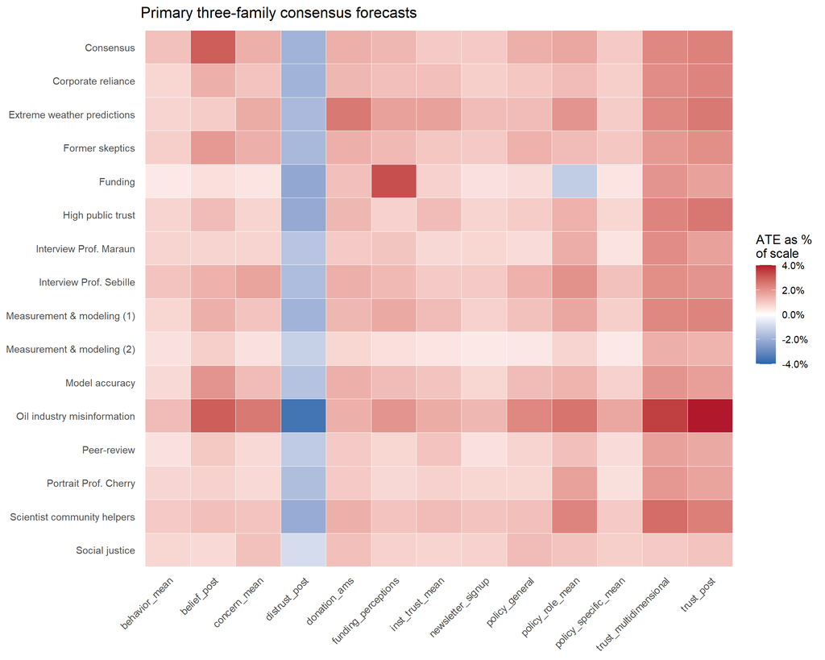

The pale or saturated color of a tile reflects the magnitude of its forecast relative to that outcome’s possible range. It does not represent uncertainty or accuracy; human benchmark outcomes were unavailable when these predictions were generated and locked.

# 4 Forecast magnitude by outcome

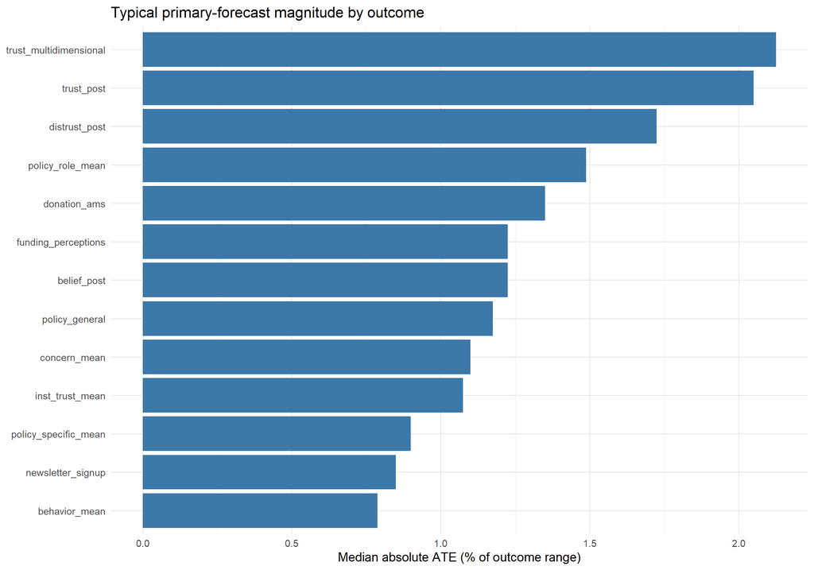

# 5 Prompt robustness

Prompt agreement tests whether the two fixed wording variants elicit similar forecasts from the same primary model. Strong agreement is desirable for stability, but two prompts can agree and still share the same bias.

Prompt-variant agreement across the 208 cells

| Model | Pearson | Spearman |
| --- | --- | --- |
| Claude Opus 4.6 | 0.910 | 0.779 |
| Gemini 3.1 Pro Preview | 0.933 | 0.885 |
| GPT-5 mini | 0.904 | 0.798 |

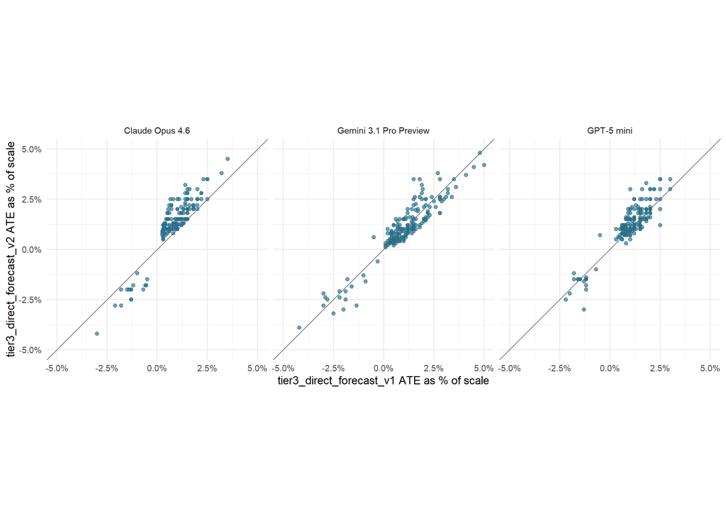

## 5.1 Cells most sensitive to prompt wording

The table identifies individual primary-model cells with the largest absolute gap between the two prompt variants. The figure then summarizes, for each outcome and model, the median gap across interventions. These are stability diagnostics, not measures of forecast magnitude or accuracy.

Largest within-model prompt ranges among primary models

| Model | Intervention | Outcome | Prompt range (% of scale) |
| --- | --- | --- | --- |
| Gemini 3.1 Pro Preview | Extreme weather predictions | donation_ams | 2.00 |
| GPT-5 mini | High public trust | donation_ams | 2.00 |
| Claude Opus 4.6 | Peer-review | trust_post | 1.85 |
| Claude Opus 4.6 | Measurement & modeling (1) | trust_post | 1.80 |
| GPT-5 mini | High public trust | distrust_post | 1.70 |
| Claude Opus 4.6 | Interview Prof. Maraun | trust_multidimensional | 1.70 |
| Gemini 3.1 Pro Preview | Measurement & modeling (1) | trust_multidimensional | 1.70 |
| Claude Opus 4.6 | Portrait Prof. Cherry | trust_multidimensional | 1.60 |
| Claude Opus 4.6 | Interview Prof. Maraun | trust_post | 1.50 |
| Claude Opus 4.6 | Peer-review | trust_multidimensional | 1.50 |
| Claude Opus 4.6 | Interview Prof. Sebille | policy_role_mean | 1.50 |
| Claude Opus 4.6 | Measurement & modeling (1) | trust_multidimensional | 1.50 |
| GPT-5 mini | High public trust | trust_post | 1.50 |
| Claude Opus 4.6 | Portrait Prof. Cherry | trust_post | 1.45 |
| Gemini 3.1 Pro Preview | Interview Prof. Maraun | distrust_post | 1.45 |

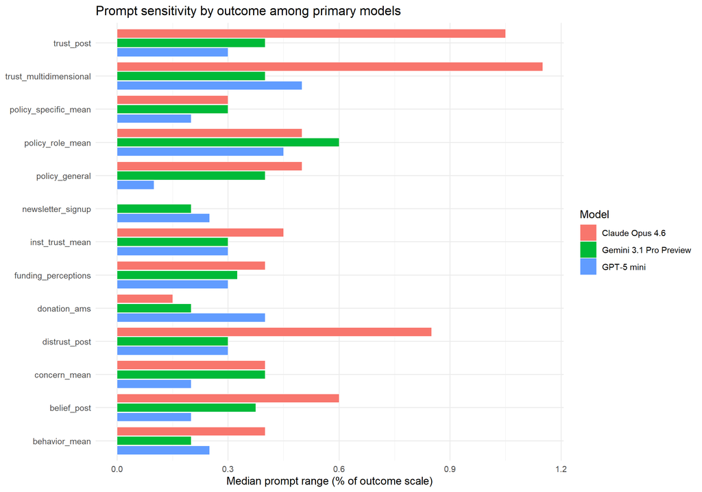

# 6 Agreement among the primary models

**What model agreement measures**  
Agreement asks whether the three primary models assign similar relative effect patterns across the same 208 intervention–outcome cells. Pearson correlation emphasizes similarity in forecast magnitudes, while Spearman correlation emphasizes similarity in rank ordering. High agreement supports the claim that the consensus is not driven by a single provider family, but it is not evidence that the forecasts are accurate; accuracy can be assessed only after comparison with the locked human benchmark results.

Pairwise agreement among the three primary model forecasts

| Model pair | Pearson | Spearman | Forecast cells |
| --- | --- | --- | --- |
| Claude Opus 4.6 vs. GPT-5 mini | 0.885 | 0.739 | 208 |
| Claude Opus 4.6 vs. Gemini 3.1 Pro Preview | 0.903 | 0.779 | 208 |
| Gemini 3.1 Pro Preview vs. GPT-5 mini | 0.889 | 0.781 | 208 |

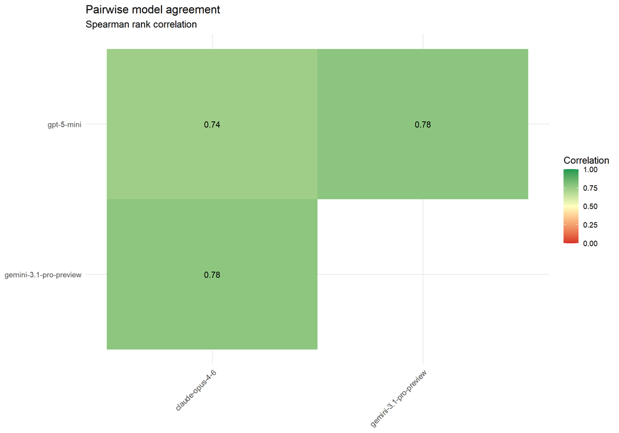

Across the three model pairs, Pearson correlations range from 0.885 to 0.903, and Spearman correlations range from 0.739 to 0.781. The full all-model agreement and prompt-sensitivity analyses remain in the separate exploratory diagnostics report.

Cells with the largest range across the three primary models

| Intervention | Outcome | Model range (% of scale) |
| --- | --- | --- |
| Funding | policy_role_mean | 2.45 |
| Consensus | belief_post | 2.10 |
| Consensus | donation_ams | 1.80 |
| Funding | funding_perceptions | 1.80 |
| Oil industry misinformation | distrust_post | 1.70 |
| Oil industry misinformation | trust_post | 1.70 |
| High public trust | donation_ams | 1.60 |
| Oil industry misinformation | belief_post | 1.45 |
| Extreme weather predictions | trust_post | 1.45 |
| Social justice | behavior_mean | 1.45 |
| Extreme weather predictions | distrust_post | 1.35 |
| Former skeptics | belief_post | 1.35 |
| Scientist community helpers | trust_multidimensional | 1.35 |
| Corporate reliance | donation_ams | 1.30 |
| Oil industry misinformation | donation_ams | 1.30 |

# 7 Reproducibility note

The prediction pipeline retains the fixed prompt texts, model routing and generation settings, structured completion records with row-level provenance, hierarchical aggregation outputs, and the final Tier-3 file. The definitive method disclosure, blinding attestation, model-call counts, costs, and archive locations are recorded in the benchmark’s required `registration.md` and `metadata.json`. This report is a supplementary human-readable summary; the locked prediction CSV and completed registration are the scored submission materials.